# STAT 118: Notes L

Plotting Points on Maps

Author

Affiliation

Andrew Villeneuve

University of New Hampshire

```r
#LOAD packages
library(sf)
library(tidyverse)
library(rnaturalearth)
library(rnaturalearthdata)
```

```r
#LOAD shapefiles
#ne countries retrieves sf shapefiles for countries around the world
world <- ne_countries(returnclass = "sf",scale="medium")
class(world)
```

```
[1] "sf"         "data.frame"
```

# More `sf` maps with points

Let’s make a global map which shows country borders.

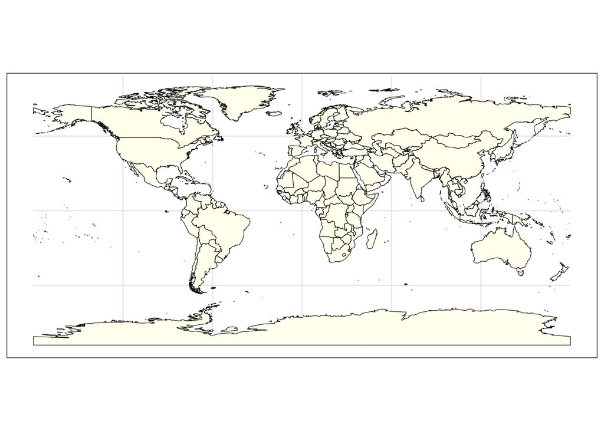

```r
#basic map

ggplot(data=world)+
  geom_sf(fill = "ivory", color = "black")+
  theme_bw()
```

We are going to visualize global fishing landings in 2012 from a UN FAO report that ranked the top 100 fishing ports by metric landings.

The dataframe `ports` contains 8 variables:

- `port` - Port name
- `country` - Country of the port
- `landings_metrictons` - Metric tonnage of landings in 2012
- `latitude` - Port latitude
- `longitude` - Port longitude
- `demersal_perc` - Percentage of demersal species
- `pelagic_perc` - Percentage of pelagic species
- `shellfish_perc` - Percentage of shellfish species

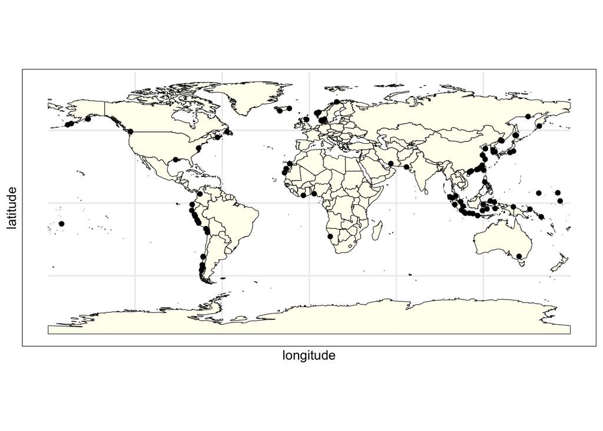

```r
ports<-read.csv("../data/landings.csv")


#let's add our sites to our map
world%>%
ggplot() +
  geom_sf(fill = "ivory", color = "black") +
  theme_bw()+
  geom_point(data=ports,aes(x=longitude,y=latitude))+
  theme()
```

Just like in non-map ggplot, we can alter the aesthetics of the port points by another variable in our dataframe. Here, we will change the size of our points based on the weight of fisheries landings.

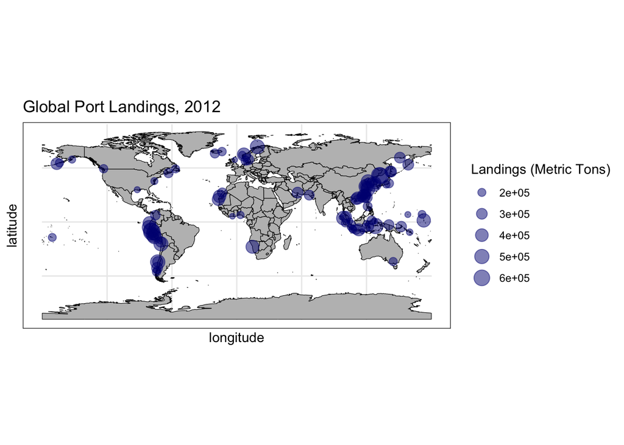

```r
#size by number oflandings
world%>%
ggplot() +
  geom_sf(fill = "gray", color = "black") +
  theme_bw()+
  geom_point(data=ports,aes(x=longitude,y=latitude,size=landings_metrictons),color="navy",alpha=0.5)+
  labs(size="Landings (Metric Tons)",title="Global Port Landings, 2012")
```

We can further restrict the geographic scope of this map by first filtering our sf world shapefile to just show Japan’s borders, and then to filter the `ports` dataframe to just show Japanese ports.

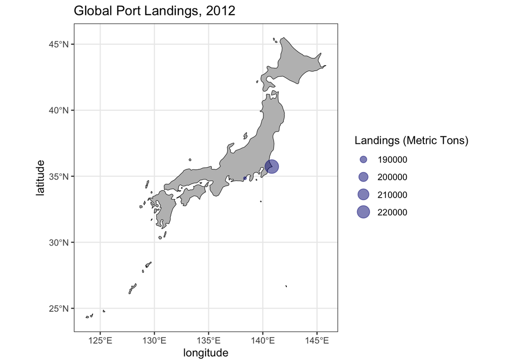

```r
world%>%
  filter(admin=="Japan")%>%
  ggplot() +
  geom_sf(fill = "gray", color = "black") +
  theme_bw()+
  geom_point(data=ports%>%filter(country=="Japan"),aes(x=longitude,y=latitude,size=landings_metrictons),color="navy",alpha=0.5)+
  labs(size="Landings (Metric Tons)",title="Global Port Landings, 2012")
```

# Leaflet

Leaflet is one of the most popular open-source JavaScript libraries for interactive maps.

```r
library(leaflet)
```

You create a Leaflet map with these basic steps:

1. Create a map widget by calling leaflet().
2. Add layers (i.e., features) to the map by using layer functions (e.g. `addTiles`, `addMarkers`, `addPolygons`) to modify the map widget.
3. Repeat step 2 as desired.

## Using OpenStreet Maps

A simple map of Tohoku University:

```r
leaflet() %>%
  addTiles() %>%
  # Add default OpenStreetMap map tiles
  addMarkers(lng=140.830833, lat=38.255528, popup="Tohoku University Faculty of Agriculture")
```

[interactive chart not shown]

A map of global landings:

```r
leaflet(data=ports) %>%
  addTiles() %>% # Add default OpenStreetMap map tiles
  addMarkers(lng=~longitude, lat=~latitude, popup=~port)
```

[interactive chart not shown]

or using Circle Markers:

```r
leaflet(data=ports) %>%
  addTiles() %>%# Add default OpenStreetMap map tiles
  addCircleMarkers(lng=~longitude, lat=~latitude, popup=~port, radius = ~landings_metrictons/100000, stroke =FALSE, fillOpacity =0.5)
```

[interactive chart not shown]